# Ethics and Practice in Data Science Final Project

International Commuters

#Overview & Goals

This markdown file will be the place where we can conduct our exploratory data analysis.

Below you will find the questions that we are using to explore the data and who is responsible for conducting the data analysis associated with that question.

By the end of this process we will have as a team:

1. Imported the cleaned dataset from Lab 3
2. All of the EDA questions examined with clear code & written explanations of the results.
3. Data visualization for the various EDAs.
   - One question to resolve is - is Lilly creating all the viz or should this be the responsibility the people assigned the questions.
   - Either way we need one coherent theme across all viz to be imported into the presentation
4. A coherent final presentation (in a separate powerpoint created by Lilly), along with a clear assignment of who is presenting what.

*General notes: >Some example code for cleaning and data analysis will be pulled into the presentation, so make sure you are annotating code as you go so we can explain what each line does if needed.

> keep committing your progress with clear messages so we can see contributions and troubleshoot errors if needed.

#Task Assignment

### 1 **1. Traffic & Volume Patterns**

> Lilly is going to be working on this question
- **How does bidding volume change across hours of the day and days of the week?**
- **When are the peak bidding periods, and what might explain those spikes?**

### 2 **2. Bid Behavior & Competitiveness**

> Edwin is going to be working on this question
- **How do bid amounts differ between winning and losing bids?**
- **Is there a relationship between bid amount and the probability of winning an auction?**
- **Do certain advertisers consistently place higher or lower bids compared to others?**

### 3 **3. Auction Outcomes**

> Bingtang is going to be working on this question
- **Which features (e.g., bid amount, time of day, advertiser) are most predictive of a win?**
- **How does the clearing price compare to the submitted bid amount across auctions?**
- **Are there systematic differences in outcomes across devices, regions, or ad categories?**

### 4 **4. Data Quality–Driven Questions**

> Neal is going to be working on this question
- **How do missing or inconsistent fields (e.g., timestamps, IDs, bid amounts) influence auction outcomes or patterns?**
- **How does the cleaned dataset change our interpretation of key trends compared to the raw data?**

#Setup

##Packages

```r
library(tidyverse)
library(arrow)
library(logger)
library(glue)
library(dplyr)
library(tidyr)
library(rlang)
library(lubridate)
library(tictoc)
library(here)
library(jsonlite)
library(scales)
library(knitr)
library(kableExtra)
library(DT)
library(tigris)   # for zctas()
library(sf)       # for spatial functions
library(stringr)  # for string cleaning
# source(here("src", "data_cleaning.r"))

#Lilly imported these from Lab 3, please feel free to add any additional libraries we might need.
```

*Note: please try to use tidyverse packages and functions, we want to make sure everyone is familiar with the functions we are using.

#Import the cleaned dataset

```r
#READ THIS BEFORE RUNNING CODE
#Since we cannot "save" the cleaned data in lab 03 please make sure to run this code "saveRDS(bids_clean, here::here("data", "bids_clean.rds"))" at line 1318 and make sure to NOT commit that change, then you can run this code


bids_clean <- readRDS(here::here("data", "bids_clean.rds"))
```

#Run Exploratory Data Analysis

### 5 **1. Traffic & Volume Patterns**

***How does bidding volume change across hours of the day and days of the week?**

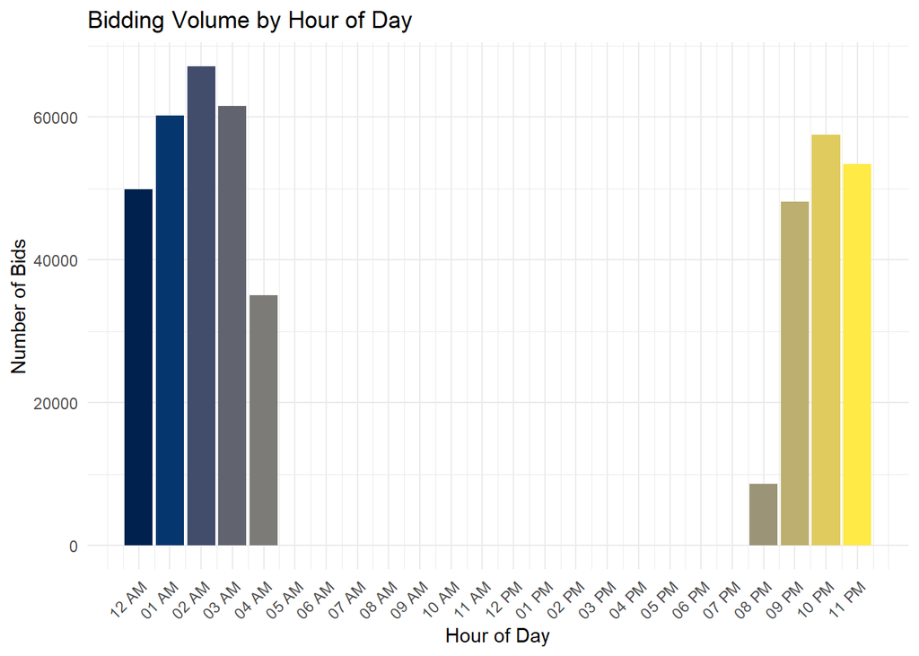

```r
# Extract hour and day of week
bids_clean <- bids_clean %>%
  mutate(
    hour = hour(TIMESTAMP_clean),
    day_of_week = wday(TIMESTAMP_clean, label = TRUE, abbr = FALSE, week_start = 1),

    day_of_week = factor(day_of_week,
                         levels = c("Monday", "Tuesday", "Wednesday", "Thursday", "Friday", "Saturday", "Sunday"),
                         ordered = FALSE)
  )

# Summarize bid volume by hour
hourly_volume <- bids_clean %>%
  count(hour)


all_days <- factor(
  c("Monday", "Tuesday", "Wednesday", "Thursday", "Friday", "Saturday", "Sunday"),
  levels = c("Monday", "Tuesday", "Wednesday", "Thursday", "Friday", "Saturday", "Sunday"),
  ordered = FALSE
)

# Summarize bid volume by day of week (include 0s)
daily_volume <- bids_clean %>%
  count(day_of_week) %>%
  complete(day_of_week = all_days, fill = list(n = 0))

# Plot: Bidding volume by hour
ggplot(hourly_volume, aes(x = hour, y = n, fill = as.factor(hour))) +
  geom_col(show.legend = FALSE) +
  scale_x_continuous(
    breaks = 0:23,
    labels = format(strptime(0:23, format = "%H"), format = "%I %p")
  ) +
  scale_fill_viridis_d(option = "cividis") +
  labs(
    title = "Bidding Volume by Hour of Day",
    x = "Hour of Day",
    y = "Number of Bids"
  ) +
  theme_minimal() +
  theme(axis.text.x = element_text(angle = 45, hjust = 1))
```

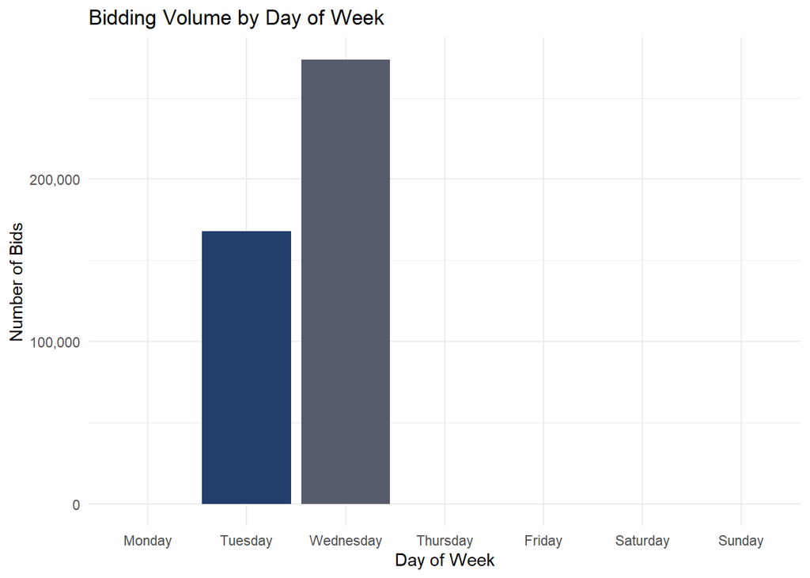

```r
# Plot: Bidding volume by day of week
ggplot(daily_volume, aes(x = day_of_week, y = n, fill = day_of_week)) +
  geom_col(show.legend = FALSE) +
  scale_y_continuous(labels = label_comma()) +
  scale_fill_viridis_d(option = "cividis") +
  labs(
    title = "Bidding Volume by Day of Week",
    x = "Day of Week",
    y = "Number of Bids"
  ) +
  theme_minimal()
```

Comments: At first I thought there was something wrong since we are only seeing results from a Tuesday and Wednesday, but after investigation, the original data set given to use only has data from 10/21/2025 and 10/22/2025, so this makes sense. This will limit the conclusions we can draw from the data, but it is not error.

Note: For the plots I intentionally added a minimal theme and made sure that the color schemes added were color-blind friendly and accessible. Specifically “cividis” is most optimized for all types of vision, including grayscale.

***When are the peak bidding periods, and what might explain those spikes?**

```r
# Identify top 3 bidding hours
top_hours <- hourly_volume %>%
  top_n(3, n) %>%
  arrange(desc(n))

# Identify peak day(s)
top_days <- daily_volume %>%
  top_n(1, n)

print(top_hours)
```

```
## # A tibble: 3 × 2
##    hour     n
##   <int> <int>
## 1     2 67111
## 2     3 61514
## 3     1 60233
```

```r
print(top_days)
```

```
## # A tibble: 1 × 2
##   day_of_week      n
##   <fct>        <int>
## 1 Wednesday   273779
```

The top three peak bidding hours are 2am, 3am, and 1am with 67,111 bids, 61,514 bids, and 60,233 bids respectively. These early hour spikes suggest that the bidding system might be automated or operating across multiple timezones (if bidders are from outside of the PST), but that is not the case here as all the bids come from OR. Another explanation could be backlogged jobs. Since it is very unlikely that these bids come from humans at these early/late hours it points to scheduled systems or ad bots.

Wednesday had the highest volume with 273,779 bids, but again we only have data from two days of the week so that does not mean much here.

### 6 **2. Bid Behavior & Competitiveness**

### 7 **3. Auction Outcomes**

### 8 **4. Data Quality–Driven Questions**

#Data Visualization

#Synthesis

*Notes: Things to make clear in the sythesis portion of this all for our own use:

> What were points of uncertainity? What steps did we take to address them and how could they still be showing up? How did we clean and prepare the data set for our work? What choices did we make and how did we standardize?

#Presentation Assignment:

##We will decide who is generating what info and transferring it to the slides. ##We also need to decide who will present what and how to field questions.

Final presentation ask: Your final presentation, in **20–30 minutes**, should tell a clear, professional story of your team’s data-cleaning workflow, exploratory analysis, and collaboration practices. The goal is to demonstrate not only what you found, but how you worked as a data science team.

Things we need to include in the final presentation:

Key Issues You Found Examples include: • Missingness patterns • Formatting inconsistencies (dates, numeric/character mismatches, categorical typos) • Duplicates • Outliers or implausible values • Structural issues (names, types, consistency)

Your Cleaning Strategy For each issue: • What you observed • Why it was a problem • Principle behind your fix (e.g., “We chose this imputation strategy because…”) • Concise R code or pseudo-code Focus on justifying decisions, not on full code dumps.

Reproducibility and Workflow Highlight: • Git usage (branches, PRs, merge conflicts) • Script modularity and readability • R Markdown / Quarto documentation • Naming conventions and folder structure

EDA Overview Patterns Show: • Distributions • Key relationships • Missingness profiles • Surprising patterns

Deep Dives on Guiding Questions For each: • State the question • Show relevant figures • Interpret results clearly • Connect to cleaning decisions

Visualization Quality Ensure: • Clear labels/titles • Good color choices • No clutter • Interpretation accompanies each visual

Insights Summarize: • 3–5 most important findings • What the data suggests overall • Uncertainties or next steps

Collaboration Reflection Discuss: • What went well in your workflow • What was challenging • Lessons learned for future projects • How GitHub, Jira, and RStudio supported collaboration

GitHub Repository Checklist Confirm your repo includes: • Clean README • Data cleaning scripts • EDA scripts (.qmd or .Rmd) • Clear folder structure (data/, R/, figs/) • Kanban snapshot • Evidence of teamwork (commit history, pull requests, etc.)